© Bản quyền thuộc về Quantopian Inc.  
© Bản quyền sửa đổi thuộc về AI Cafe¹  
Giấy phép [Creative Commons Attribution 4.0](https://creativecommons.org/licenses/by/4.0/legalcode).  
[Khuyến cáo](https://aicafe.one/khuyen-cao/)

# Khoảng Tin Cậy

By Delaney Granizo-Mackenzie, Jeremiah Johnson, and Gideon Wulfsohn

Edited by AI Cafe¹

## Trung bình mẫu so với trung bình tổng thể

Trung bình mẫu và trung bình tổng thể là khác nhau. Nói chung, chúng ta muốn biết về trung bình tổng thể, nhưng chúng ta chỉ có thể tính toán trung bình mẫu. Sau đó, chúng ta muốn sử dụng trung bình mẫu để ước lượng trung bình tổng thể. Chúng ta sử dụng khoảng tin cậy để cố gắng xác định mức độ chính xác mà trung bình mẫu ước lượng trung bình tổng thể.

## Khoảng Tin Cậy

Nếu tôi yêu cầu bạn ước lượng chiều cao trung bình của một người phụ nữ Việt Nam, bạn có thể làm điều này bằng cách đo 10 người phụ nữ và ước lượng rằng trung bình của mẫu đó gần với tổng thể. Hãy thử điều đó.

```python
import numpy as np
from scipy import stats
import matplotlib.pyplot as plt
```

```python
# We'll set a seed here so our runs are consistent
np.random.seed(10)

# Let's define some 'true' population parameters, we'll pretend we don't know these.
POPULATION_MU = 160
POPULATION_SIGMA = 15

# Generate our sample by drawing from the population distribution
sample_size = 10
heights = np.random.normal(POPULATION_MU, POPULATION_SIGMA, sample_size)
print(heights)
mean_height = np.mean(heights)
print('sample mean:', mean_height)
```

```
[179.97379756 170.72918462 136.81899562 159.87424225 169.32003961
 149.19871659 163.98267379 161.62822789 160.06437146 157.38099684]
sample mean: 160.89712462211185
```

Thật không may, việc chỉ báo cáo trung bình mẫu không giúp ích cho chúng ta nhiều, vì chúng ta không biết nó liên quan như thế nào đến trung bình tổng thể. Để có cái nhìn về cách nó có thể liên quan, chúng ta có thể xem xét mức độ biến thiên trong mẫu của mình. Biến thiên cao cho thấy sự không ổn định và không chắc chắn.

```python
print('sample standard deviation: ', np.std(heights))
```

```
sample standard deviation:  11.27963405536393
```

Điều này vẫn chưa thực sự giúp chúng ta nhiều, để có thể hiểu rõ mối quan hệ giữa trung bình mẫu và trung bình tổng thể, chúng ta cần tính toán sai số chuẩn. Sai số chuẩn là một thước đo độ biến thiên của trung bình mẫu.

QUAN TRỌNG: Việc tính toán sai số chuẩn liên quan đến giả định rằng cách bạn lấy mẫu là không thiên lệch, và rằng dữ liệu là phân phối chuẩn và độc lập. Nếu các điều kiện này bị vi phạm, sai số chuẩn của bạn sẽ sai. Có những cách để kiểm tra điều này và điều chỉnh.

Công thức tính sai số chuẩn là:

$$SE = \frac{\sigma}{\sqrt{n}}$$

Trong đó $\sigma$ là độ lệch chuẩn mẫu và $n$ là số lượng mẫu.

```python
SE = np.std(heights) / np.sqrt(sample_size)
print('standard error:', SE)
```

```
standard error: 3.5669334788151814
```

Có một hàm trong thư viện stats của scipy để tính toán sai số chuẩn. Lưu ý rằng hàm này mặc định có một điều chỉnh bậc tự do mà thường không cần thiết (đối với các mẫu đủ lớn, nó thực sự không quan trọng). Bạn có thể bỏ qua điều chỉnh này bằng cách đặt tham số ddof thành 0.

```python
stats.sem(heights, ddof=0)
```

```
np.float64(3.5669334788151814)
```

Để tính khoảng tin cậy 95% cho dữ liệu phân phối chuẩn, bạn cần xác định số độ lệch chuẩn chứa 95% lượng giá trị. Trong phân phối chuẩn, 95% lượng giá trị nằm giữa -1.96 và 1.96. Khi kích thước mẫu lớn (thường là > 30), Định lý Giới hạn Trung tâm (Central Limit Theorem) có thể được áp dụng và bạn có thể giả định rằng dữ liệu có phân phối chuẩn. Nếu kích thước mẫu nhỏ hơn, bạn nên sử dụng phân phối t với bậc tự do được chỉ định phù hợp.

Để tính toán các giá trị này, bạn sẽ sử dụng hàm phân phối tích lũy (Cumulative Distribution Function - CDF). Nếu bạn chưa quen với CDF, các hàm CDF ngược và PDF tương ứng, bạn có thể đọc thêm [tại đây](https://en.wikipedia.org/wiki/Probability_density_function) và [tại đây](https://en.wikipedia.org/wiki/Cumulative_distribution_function). Để tìm hiểu về phân phối t, hãy xem thông tin [tại đây](https://en.wikipedia.org/wiki/Student%27s_t-distribution).

Lưu ý rằng khi áp dụng Định lý Giới hạn Trung tâm, cần cẩn thận vì nhiều bộ dữ liệu trong tài chính có thể không phân phối chuẩn và việc áp dụng định lý này một cách tùy tiện có thể dẫn đến sai sót.

Bạn có thể trực quan hóa các giới hạn lượng giá trị trong 95% bằng cách sử dụng các công cụ lập trình như Python.

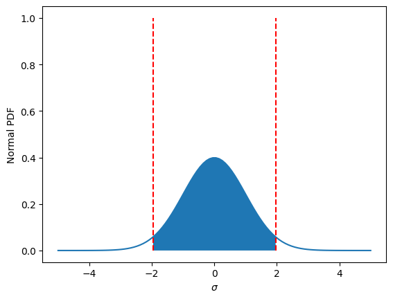

```python
# Set up the x axis
x = np.linspace(-5,5,100)
# Here's the normal distribution
y = stats.norm.pdf(x,0,1)
plt.plot(x,y)

# Plot our bounds
plt.vlines(-1.96, 0, 1, colors='r', linestyles='dashed')
plt.vlines(1.96, 0, 1, colors='r', linestyles='dashed')

# Shade the area
fill_x = np.linspace(-1.96, 1.96, 500)
fill_y = stats.norm.pdf(fill_x, 0, 1)
plt.fill_between(fill_x, fill_y)

plt.xlabel(r'$\sigma$')
plt.ylabel('Normal PDF');
```

Bây giờ, thay vì báo cáo giá trị trung bình mẫu của chúng ta mà không có cảm giác về xác suất của nó là chính xác, chúng ta có thể tính toán một khoảng và tự tin hơn rằng giá trị trung bình của tổng thể nằm trong khoảng đó. Để làm điều này, chúng ta lấy giá trị trung bình mẫu $\mu$ và báo cáo $\left(\mu-1.96 SE , \mu+1.96SE\right)$.

Điều này có hiệu quả vì giả định rằng khoảng đó sẽ chứa giá trị trung bình của tổng thể trong 95% các trường hợp.

SỰ TINH TẾ: Trong bất kỳ trường hợp nào, giá trị thực của ước lượng và các giới hạn của khoảng tin cậy là cố định. Việc nói rằng "Giá trị trung bình chiều cao nữ quốc gia nằm giữa 152 và 168 cm với xác suất 95%" là không chính xác, nhưng thật không may đây là một sự hiểu lầm rất phổ biến. Thay vào đó, 95% đề cập đến thực tế rằng qua nhiều lần tính toán khoảng tin cậy 95%, giá trị thực sẽ nằm trong khoảng 95% các trường hợp (giả định rằng khoảng tin cậy được hiệu chỉnh đúng, điều mà chúng ta sẽ thảo luận sau). Nhưng thực tế, đối với một mẫu đơn lẻ và khoảng tin cậy đơn lẻ được tính từ nó, chúng ta không có cách nào để đánh giá xác suất rằng khoảng đó chứa giá trị trung bình của tổng thể. Hình ảnh dưới đây minh họa điều này.

Trong khối mã dưới đây, có hai điều cần lưu ý. Đầu tiên, mặc dù kích thước mẫu đủ lớn để giả định phân phối chuẩn, chúng ta đang sử dụng phân phối $t$, chỉ để minh họa cách nó được sử dụng. Thứ hai, các giá trị $t$ cần thiết (tương tự như $\pm1.96$ được sử dụng ở trên) đang được tính toán từ hàm phân phối tích lũy đảo ngược, ppf trong scipy.stats. Phân phối $t$ yêu cầu tham số tự do bổ sung (d.o.f), là kích thước mẫu trừ đi một.

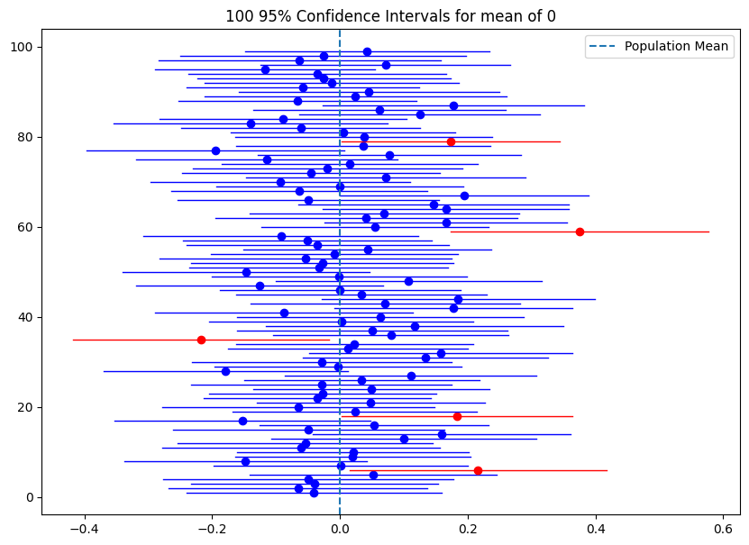

```python
np.random.seed(8309)
n = 100 # number of samples to take
samples = [np.random.normal(loc=0, scale=1, size=100) for _ in range(n)]

fig, ax = plt.subplots(figsize=(10, 7))
for i in np.arange(1, n, 1):
    sample_mean = np.mean(samples[i])  # calculate sample mean
    se = stats.sem(samples[i])  # calculate sample standard error
    h = se*stats.t.ppf((1+0.95)/2, len(samples[i])-1) # calculate t; 2nd param is d.o.f.
    sample_ci = [sample_mean - h, sample_mean + h]
    if ((sample_ci[0] <= 0) and (0 <= sample_ci[1])):
        plt.plot((sample_ci[0], sample_ci[1]), (i, i), color='blue', linewidth=1);
        plt.plot(np.mean(samples[i]), i, 'bo');
    else:
        plt.plot((sample_ci[0], sample_ci[1]), (i, i), color='red', linewidth=1);
        plt.plot(np.mean(samples[i]), i, 'ro');
plt.axvline(x=0, ymin=0, ymax=1, linestyle='--', label = 'Population Mean');
plt.legend(loc='best');
plt.title('100 95% Confidence Intervals for mean of 0');
```

Hãy quay lại ví dụ về chiều cao của chúng ta. Bởi vì kích thước mẫu nhỏ, chúng ta sẽ sử dụng bài kiểm tra $t$.

```python
# standard error SE was already calculated
t_val = stats.t.ppf((1+0.95)/2, 9)  # d.o.f. = 10 - 1
print('sample mean height:', mean_height)
print('t-value:', t_val)
print('standard error:', SE)
print('confidence interval:', (mean_height - t_val * SE, mean_height + t_val * SE))
```

```
sample mean height: 160.89712462211185
t-value: 2.2621571628540993
standard error: 3.5669334788151814
confidence interval: (np.float64(152.828160503586), np.float64(168.9660887406377))
```

Có một hàm tích hợp trong scipy.stats để tính toán khoảng tin cậy. Hãy nhớ chỉ định số bậc tự do.

```python
print('99% confidence interval:', stats.t.interval(0.99, df=9,
                                                   loc=mean_height, scale=SE))
print('95% confidence interval:', stats.t.interval(0.95, df = 9,
                                                   loc=mean_height, scale=SE))
print('80% confidence interval:', stats.t.interval(0.8, df = 9,
                                                   loc=mean_height, scale=SE))
```

```
99% confidence interval: (np.float64(149.30517742816343), np.float64(172.48907181606026))
95% confidence interval: (np.float64(152.828160503586), np.float64(168.9660887406377))
80% confidence interval: (np.float64(155.96395311296186), np.float64(165.83029613126183))
```

Lưu ý rằng khi sự tự tin của bạn tăng lên, khoảng tin cậy sẽ phải mở rộng.

Giả sử phân phối chuẩn, cũng có một hàm được tích hợp sẵn sẽ tính toán khoảng tin cậy cho chúng ta. Lần này bạn không cần phải chỉ định bậc tự do. Lưu ý rằng tại một mức độ tin cậy tương ứng, khoảng tin cậy được tính toán bằng phân phối chuẩn hẹp hơn khoảng tin cậy được tính toán bằng phân phối $t$.

```python
print(stats.norm.interval(0.99, loc=mean_height, scale=SE))
print(stats.norm.interval(0.95, loc=mean_height, scale=SE))
print(stats.norm.interval(0.80, loc=mean_height, scale=SE))
```

```
(np.float64(151.70931284357007), np.float64(170.08493640065362))
(np.float64(153.90606346838393), np.float64(167.88818577583976))
(np.float64(156.3259154381428), np.float64(165.4683338060809))
```

Khoảng tin cậy cho phép chúng ta thiết lập mức độ tin cậy mong muốn và sau đó báo cáo một khoảng mà có khả năng chứa trung bình quần thể. Chúng ta mong muốn mức độ tin cậy càng cao, khoảng mà chúng ta báo cáo càng lớn. Nói chung, không bao giờ có thể báo cáo một giá trị điểm duy nhất, vì xác suất mà bất kỳ điểm nào được chọn là trung bình quần thể thực sự là cực kỳ nhỏ. Hãy xem cách mà các khoảng của chúng ta thu hẹp lại khi chúng ta thay đổi kích thước mẫu.

```python
np.random.seed(10)

sample_sizes = [10, 100, 1000]
for s in sample_sizes:
    heights = np.random.normal(POPULATION_MU, POPULATION_SIGMA, s)
    SE = np.std(heights) / np.sqrt(s)
    print(stats.norm.interval(0.95, loc=mean_height, scale=SE))
```

```
(np.float64(153.90606346838393), np.float64(167.88818577583976))
(np.float64(158.03107608983976), np.float64(163.76317315438394))
(np.float64(160.01780019421867), np.float64(161.77644905000503))
```

## Trực quan hóa Khoảng tin cậy

Dưới đây là một số code để biểu diễn khoảng tin cậy trên một đồ thị. Bạn có thể thoải mái thử nghiệm với nó.

```
(np.float64(158.76656265974063), np.float64(164.72039078630425))
```

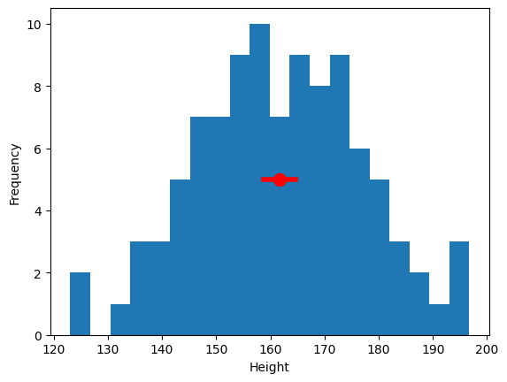

```python
sample_size = 100
heights = np.random.normal(POPULATION_MU, POPULATION_SIGMA, sample_size)
SE = np.std(heights) / np.sqrt(sample_size)
(l, u) = stats.norm.interval(0.95, loc=np.mean(heights), scale=SE)

print((l, u))

plt.hist(heights, bins=20)
plt.xlabel('Height')
plt.ylabel('Frequency')

# Just for plotting
y_height = 5
plt.plot([l, u], [y_height, y_height], '-', color='r', linewidth=4, label='Confidence Interval')
plt.plot(np.mean(heights), y_height, 'o', color='r', markersize=10);
```

## Thiếu chính xác và Vi phạm giả định

Việc tính toán độ lệch chuẩn, sai số chuẩn và khoảng tin cậy đều phụ thuộc vào một số giả định nhất định. Nếu những giả định này bị vi phạm, thì khoảng tin cậy 95% sẽ không nhất thiết chứa tham số quần thể 95% trường hợp. Chúng ta nói rằng trong trường hợp này, khoảng tin cậy là thiếu chính xác. Dưới đây là một ví dụ.

### Ví dụ: Dữ liệu Tự Tương Quan

Nếu quá trình sinh dữ liệu của bạn có tính tự tương quan, thì các ước lượng độ lệch chuẩn sẽ sai. Điều này là do các quá trình tự tương quan có xu hướng tạo ra nhiều giá trị cực đoan hơn so với các quá trình phân phối chuẩn. Điều này xảy ra vì các giá trị mới phụ thuộc vào các giá trị trước đó, các chuỗi đã ở xa trung bình có khả năng sẽ vẫn ở xa trung bình. Để kiểm tra điều này, chúng ta sẽ tạo ra một số dữ liệu tự tương quan theo quá trình sau.

$$X_t = \theta X_{t-1} + \epsilon$$ $$\epsilon \sim \mathcal{N}(0,1)$$

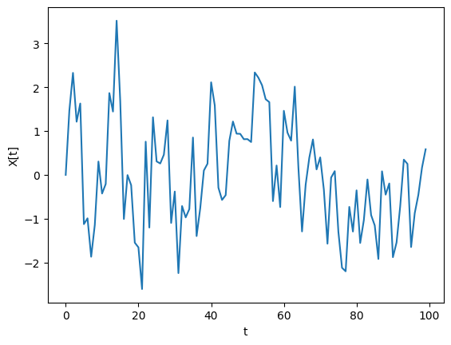

```python
def generate_autocorrelated_data(theta, mu, sigma, N):
    # Initialize the array
    X = np.zeros((N, 1))

    for t in range(1, N):
        # X_t = theta * X_{t-1} + epsilon
        X[t] = theta * X[t-1] + np.random.normal(mu, sigma)
    return X

X = generate_autocorrelated_data(0.5, 0, 1, 100)

plt.plot(X);
plt.xlabel('t');
plt.ylabel('X[t]');
```

Hóa ra rằng đối với kích thước mẫu lớn hơn, bạn nên thấy giá trị trung bình mẫu dần dần hội tụ về không. Điều này là bởi vì quá trình vẫn được trung tâm quanh giá trị không, nhưng hãy kiểm tra xem điều đó có đúng không. Chúng ta sẽ thay đổi số lượng mẫu được lấy và tìm kiếm sự hội tụ khi chúng ta tăng kích thước mẫu.

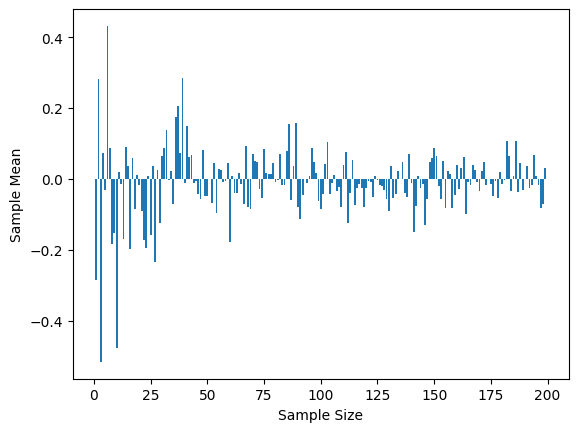

```python
sample_means = np.zeros(200-1)
for i in range(1, 200):
    X = generate_autocorrelated_data(0.5, 0, 1, i * 10)
    sample_means[i-1] = np.mean(X)

plt.bar(range(1, 200), sample_means);
plt.xlabel('Sample Size');
plt.ylabel('Sample Mean');
```

Có vẻ như chắc chắn có sự hội tụ, chúng ta cũng có thể kiểm tra giá trị trung bình của các giá trị trung bình mẫu.

```python
np.mean(sample_means)
```

```
np.float64(-0.008571996202976648)
```

Gần như bằng không. Chúng ta cũng có thể suy ra một cách biểu tượng rằng trung bình là 0, nhưng hãy giả sử rằng chúng ta đã tự thuyết phục mình bằng một phân tích thực nghiệm đơn giản. Bây giờ chúng ta đã biết trung bình của quần thể, chúng ta có thể kiểm tra độ hiệu chỉnh của các khoảng tin cậy. Đầu tiên, chúng ta sẽ viết hai hàm trợ giúp để tính toán một khoảng đơn giản cho một số dữ liệu đầu vào và kiểm tra xem khoảng này có chứa trung bình thực, 0 hay không.

```python
def compute_unadjusted_interval(X):
    T = len(X)
    # Compute mu and sigma MLE
    mu = np.mean(X)
    sigma = np.std(X)
    SE = sigma / np.sqrt(T)
    # Compute the bounds
    return stats.norm.interval(0.95, loc=mu, scale=SE)

# We'll make a function that returns true when the computed bounds contain 0
def check_unadjusted_coverage(X):
    l, u = compute_unadjusted_interval(X)
    # Check to make sure l <= 0 <= u
    if l <= 0 and u >= 0:
        return True
    else:
        return False
```

Bây giờ chúng ta sẽ tiến hành nhiều thử nghiệm, trong mỗi thử nghiệm chúng ta sẽ lấy mẫu một số dữ liệu, tính toán một khoảng tin cậy và sau đó kiểm tra xem khoảng tin cậy có chứa giá trị trung bình của tập tổng thể hay không. Chúng ta sẽ giữ một bản tổng hợp liên tục, và chúng ta nên kỳ vọng thấy 95% số thử nghiệm thành công nếu các khoảng này được hiệu chỉnh đúng cách.

```python
from IPython.display import clear_output

T = 100
trials = 500
times_correct = 0
for i in range(trials):
    print(f"trial {i+1} of {trials}")
    X = generate_autocorrelated_data(0.5, 0, 1, T)
    if check_unadjusted_coverage(X):
        times_correct += 1
    clear_output(wait=True)

print('Empirical Coverage:', times_correct/float(trials))
print('Expected Coverage:', 0.95)
```

```
Empirical Coverage: 0.732
Expected Coverage: 0.95
```

Rõ ràng là độ bao phủ là sai. Trong trường hợp này, chúng ta cần thực hiện cái được gọi là điều chỉnh Newey-West trên ước lượng sai số chuẩn của chúng ta để tính đến sự tự tương quan. Trong thực tế, việc kiểm tra các giả định mà bạn đưa ra là rất quan trọng. Việc kiểm tra nhanh chóng và dễ dàng xem liệu dữ liệu của bạn có ổn định (điều này ngụ ý không có tự tương quan) hay không, và điều này có thể giúp bạn tránh được rất nhiều đau đớn và khổ sở. Một bài kiểm tra tính chuẩn như `Jarque Bera` cũng sẽ là một ý tưởng tốt, vì nó có thể phát hiện một số tính chất phân phối có thể vi phạm các giả định của nhiều phân tích thống kê tiếp theo.

*Lưu ý: Tài liệu này mang tính chất chia sẻ kiến thức khoa học dữ liệu. Các mã chứng khoán xuất hiện trong tài liệu chỉ mang tính chất minh hoạ, không khuyến nghị đầu tư. Chúng tôi không chịu trách nhiệm trước mọi rủi ro nào do sử dụng tài liệu này.*